# Make ASCE_SIFT_Region2 dtopo file

This Jupyter notebook is available in `$GTT/dtopo/ASCE_SIFT_Region2.ipynb` within the [GeoClaw Tsunami Tutorial](https://rjleveque.github.io/geoclaw_tsunami_tutorial).

It creates the file `$GTT/dtopo/dtopofiles/ASCE_SIFT_Region2.dtt3`, which can be used as a [dtopofile](https://www.clawpack.org/dtopo.html) in GeoClaw.

:::{admonition}To Do :class: dropdown

- Add more description of ASCE, SIFT, unit sources
- Plot transects
- Make dtopo contours in kmz file :::

:::{seealso}

- [dtopotools_examples notebook](https://www.clawpack.org/gallery/_static/apps/notebooks/geoclaw/dtopotools_examples.html)
- [Okada notebook](https://www.clawpack.org/gallery/_static/apps/notebooks/geoclaw/Okada.html) :::

Rather than building this dtopofile, it is also possible to download it using `GTT/dtopo/fetch_ASCE_SIFT_Region2.py`.

:::{warning} This notebook currently fails when building the Jupyter Book on Github because it requires reading a text file that is not available in the `pip install` version of Clawpack. This should be fixed with the next Clawpack release, which will include [GeoClaw PR #672](https://github.com/clawpack/geoclaw/pull/672). :::

:::{note} This should be fixed in Version 5.13.1 (9/12/25). :::

### Setup notebook and environment:

```python
%matplotlib inline
```

```python
from pylab import *
from clawpack.geoclaw import dtopotools, topotools
```

#### Check if this notebook will fail (see Warning above):

Debugging....

```python
import clawpack
print('Using clawpack version %s' % clawpack.__version__)
try:
    f = dtopotools.SiftFault()
    print('This notebook should run fine')
except:
    print('This notebook will fail due to the problem in the Warning above.')
    print('But here is the plot it should produce:')
    image = imread('dtopofiles/ASCE_SIFT_Region2.png')
    figure(figsize=(12,6))
    imshow(image)
    axis('off')
```

```
Using clawpack version 5.13.1
This notebook should run fine
```

#### Load shoreline for plotting:

```python
csz_shore = loadtxt('../topo/topofiles/csz_shore.txt')
```

## Create a fault using the NOAA SIFT database

This particular fault is specified in terms of the NOAA SIFT unit sources, so we can use the clawpack.geoclaw.dtopotools.SiftFault class, which takes as an argument a dictionary *sift_slip* specifying the unit sources to be used and the slip on each.

First we plot some of the unit sources on the CSZ margin.

```python
f = dtopotools.SiftFault()
SIFT = f.sift_subfaults
sift_slips = {}
for k in SIFT.keys():
    s = SIFT[k]  # subfault
    s.longitude = s.longitude - 360.
    if (-130 <=s.longitude <= -120) and (44 <= s.latitude <= 50):
        if (k[4] in ['a','b']):
            sift_slips[k] = 0.
```

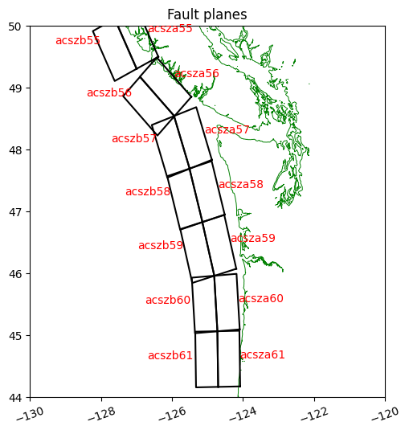

```python
csz = dtopotools.SiftFault(sift_slips)
for k in sift_slips.keys():
    s = csz.sift_subfaults[k]  # subfault
    s.longitude = s.longitude - 360.

figure(figsize=(6,6))
ax = axes()
ax.plot(csz_shore[:,0], csz_shore[:,1], 'g', linewidth=0.7)
#axis([-140,-110,43,50])
ax.set_xlim(-130,-120)
ax.set_ylim(44,50)
csz.plot_subfaults(axes=ax)
ax.set_aspect(1./cos(55*pi/180.))

for k in sift_slips.keys():
    s = csz.sift_subfaults[k]  # subfault
    if k[4] == 'a':
        text(s.longitude, s.latitude, k, color='r')
    else:
        text(s.longitude-2, s.latitude, k, color='r')
```

Slips provided by Yong Wei: 35*ac57a+35*ac57b+10*ac58a+33*ac58b+10*ac59a+24*ac59b+30*ac60a+30*ac60b

```python
sift_slips = {'acsza57':35, 'acszb57':35 , 'acsza58':10 , 'acszb58':33 , 'acsza59':10 , 'acszb59':24 ,
              'acsza60':30 , 'acszb60':30 }
fault = dtopotools.SiftFault(sift_slips)
for k in sift_slips.keys():
    s = fault.sift_subfaults[k]  # subfault
    s.longitude = s.longitude - 360.
```

```python
x,y = fault.create_dtopo_xy(dx=10./3600., buffer_size=1)
print(x.shape, y.shape)
```

```
(1801,) (2161,)
```

```python
y.min(), y.max()
```

```
(np.float64(44.032340382650645), np.float64(50.032340382650645))
```

```python
print('Creating dtopo by applying Okada model to %s subfaults...' % len(fault.subfaults))
dtopo_SIFT = fault.create_dtopography(x,y, verbose=False)
print('Done')
```

```
Creating dtopo by applying Okada model to 8 subfaults...
Done
```

## Plot the slip distribution and the resulting vertical deformation dz

```
maximum abs(dz) over the full rupture time: 17.93480928266853
Created  dtopofiles/ASCE_SIFT_Region2.png
```

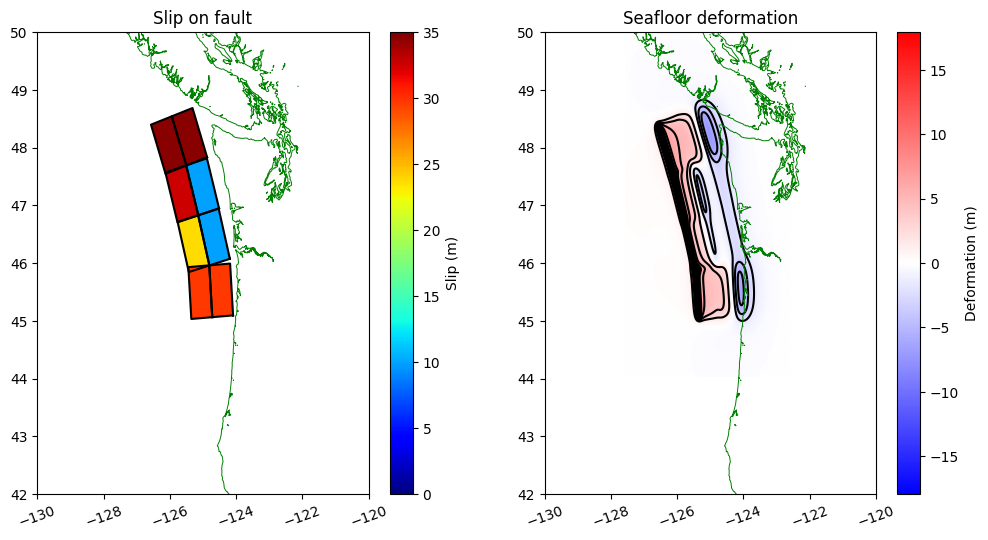

```python
# for setting color scale:
dz_max = abs(dtopo_SIFT.dZ).max()
print("maximum abs(dz) over the full rupture time:", \
    abs(dtopo_SIFT.dZ).max())

fig = figure(figsize=(12,6))
ax1 = fig.add_subplot(121)
ax2 = fig.add_subplot(122)
fault.plot_subfaults(axes=ax1, slip_color=True)
dtopo_SIFT.plot_dZ_colors(axes=ax2, t=1, cmax_dZ=dz_max)

ax1.plot(csz_shore[:,0], csz_shore[:,1], 'g', linewidth=0.7)
ax1.set_xlim(-130,-120)
ax1.set_ylim(42,50)
ax1.set_aspect(1./cos(55*pi/180.))

ax2.plot(csz_shore[:,0], csz_shore[:,1], 'g', linewidth=0.7)
ax2.set_xlim(-130,-120)
ax2.set_ylim(42,50)
ax2.set_aspect(1./cos(55*pi/180.));

fname = 'dtopofiles/ASCE_SIFT_Region2.png'
savefig(fname, bbox_inches='tight')
print('Created ',fname)
```

## Save as a dtopo file

```python
fname = 'dtopofiles/ASCE_SIFT_Region2.dtt3'
dtopo_SIFT.write(fname, dtopo_type=3)
print('Created ',fname)
```

```
Created  dtopofiles/ASCE_SIFT_Region2.dtt3
```